# forplo - flexible forest plots

vincent10kd@gmail.com  
2023-02-16

## Background

**forplo** is an R package meant to simplify the creation and customization of forest plots (alternatively called dot-and-whisker plots). Input classes accepted by **forplo** are `data.frame`, `matrix`, `lm`, `glm`, and `coxph`. **forplo** was written in base R and does not depend on other packages.

## Examples: data.frames

With **forplo**, a data.frame or matrix with exactly 3 columns can be entered in the `mat` argument, where the first column will be interpreted as the effect estimate and the second and third columns are interpreted as the lower and upper bounds of a confidence interval. By default, the row names of `mat` will be used as variable names. Alternatively, one can specify the variable names directly by entering a character vector of the same `length` as the number of rows in `mat` under `row.labels`. The left margin of the plot is automatically resized to fit the variable names, but it can be handset by changing `margin.left`. This goes for the other margins as well.

The following examples will illustrate the use of **forplo** and how the arguments may be used for customization. The data for the first example are due to Joanne E. McKenzie and Sue E. Brennan, chapter 12 of the *Cochrane Handbook for Systematic Reviews of Interventions*, version 6.2 (2021).

```r
exdf <- cbind(OR=c(1.21,0.90,1.02,
                   1.54,1.32,0.79,1.38,0.85,1.11,
                   1.58,1.80,2.27),
              LCI=c(0.82,0.61,0.66,
                    1.08,0.91,0.48,1.15,0.39,0.91,
                    0.99,1.48,0.92),
              UCI=c(1.79,1.34,1.57,
                    2.19,1.92,1.32,1.64,1.87,1.34,
                    2.54,2.19,5.59),
              groups=c(1,1,1,
                       2,2,2,2,2,2,
                       3,3,3))
exdf <- data.frame(exdf)
rownames(exdf) <- c('Barry, 2005', 'Frances, 2000', 'Rowley, 1995',
                    'Biro, 2000', 'Crowe, 2010', 'Harvey, 1996',
                    'Johns, 2004', 'Parr, 2002', 'Zhang, 2011',
                    'Flint, 1989', 'Mac Vicar, 1993', 'Turnbull, 1996')
knitr::kable(exdf)
```

|  | OR | LCI | UCI | groups |
| --- | --- | --- | --- | --- |
| Barry, 2005 | 1.21 | 0.82 | 1.79 | 1 |
| Frances, 2000 | 0.90 | 0.61 | 1.34 | 1 |
| Rowley, 1995 | 1.02 | 0.66 | 1.57 | 1 |
| Biro, 2000 | 1.54 | 1.08 | 2.19 | 2 |
| Crowe, 2010 | 1.32 | 0.91 | 1.92 | 2 |
| Harvey, 1996 | 0.79 | 0.48 | 1.32 | 2 |
| Johns, 2004 | 1.38 | 1.15 | 1.64 | 2 |
| Parr, 2002 | 0.85 | 0.39 | 1.87 | 2 |
| Zhang, 2011 | 1.11 | 0.91 | 1.34 | 2 |
| Flint, 1989 | 1.58 | 0.99 | 2.54 | 3 |
| Mac Vicar, 1993 | 1.80 | 1.48 | 2.19 | 3 |
| Turnbull, 1996 | 2.27 | 0.92 | 5.59 | 3 |

```r
forplo(exdf[,1:3])
```

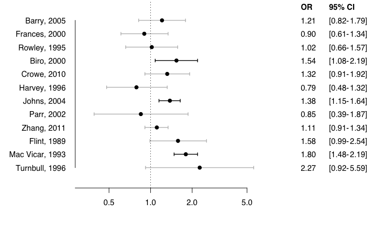

This is the default output when entering a `data.frame`. Now we will group the data by a grouping variable. When using groups, the argument `groups` is used to specify the group membership of each variable in a numeric vector (if is not numeric, it will be coerced to numeric), and a character vector of group labels of `length(unique(groups))` should be entered as `grouplabs`. If the variables are not in order of group they will be automatically sorted by group before being plotted.

```r
forplo(exdf[,1:3],
       groups=exdf$groups,
       grouplabs=c('Low risk of bias',
                   'Some concerns',
                   'High risk of bias'))
```

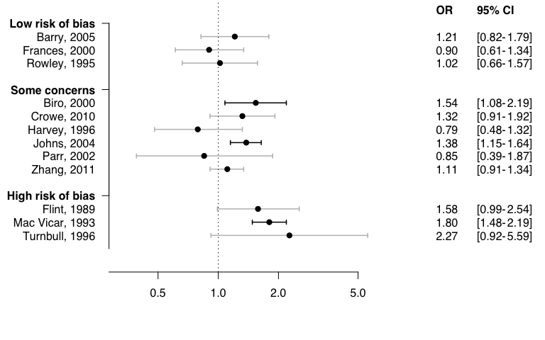

To demonstrate some more of the features of **forplo**, we will meta-analyze the studies in each group and across all studies, and create a new data.frame containing the meta-analytic estimates. We can add more columns (log OR, SE, weights) to the plot using `add.columns` and `add.colnames`. We can use diamonds to indicate meta-analytic estimates. In order to do this, we specify which estimates are diamonds by giving a numeric vector to `diamond`. Specific customization options for the diamonds are `diamond.col` and `diamond.line` (`TRUE` or `FALSE`). The diamond line is only shown for the last diamond, on the assumption that this would be the overall meta-estimate.

To make the plot a bit more interesting, we will also add some color with `col` and remove the edges from the confidence intervals by setting `ci.edge=FALSE`. We will also left align the group and study names with `left.align==TRUE`.

```r
logORs <- round(log(exdf$OR),2)
SE <- round((log(exdf$UCI)-logORs)/1.96,2)
meta1 <- meta::metagen(logORs[1:3],SE[1:3])
meta2 <- meta::metagen(logORs[4:9],SE[4:9])
meta3 <- meta::metagen(logORs[10:12],SE[10:12])
metatot <- meta::metagen(logORs,SE)
# create new data.frame
exdf2 <- exdf
exdf2$logORs <- logORs
exdf2$SE <- SE
exdf2$weights <- round(metatot$w.random/sum(metatot$w.random)*100,2)
exdf2 <- rbind(subset(exdf2,groups==1),
      c(round(exp(meta1$TE.random),2),
        round(exp(meta1$lower.random),2),
        round(exp(meta1$upper.random),2),
        1,round(meta1$TE.random,2),round(meta1$seTE.random,2),sum(exdf2$weights[1:3])),
      subset(exdf2,groups==2),
      c(round(exp(meta2$TE.random),2),
        round(exp(meta2$lower.random),2),
        round(exp(meta2$upper.random),2),
        2,round(meta2$TE.random,2),round(meta2$seTE.random,2),sum(exdf2$weights[4:9])),
      subset(exdf2,groups==3),
      c(round(exp(meta3$TE.random),2),
        round(exp(meta3$lower.random),2),
        round(exp(meta3$upper.random),2),
        3,round(meta3$TE.random,2),round(meta3$seTE.random,2),sum(exdf2$weights[10:12])),
      c(round(exp(metatot$TE.random),2),
        round(exp(metatot$lower.random),2),
        round(exp(metatot$upper.random),2),
        4,round(metatot$TE.random,2),round(metatot$seTE.random,2),100))
exdf2 <- data.frame(exdf2)
rownames(exdf2)[c(4,11,15,16)] <- c('Diamond 1','Diamond 2','Diamond 3','Diamond 4')
# show new data.frame
knitr::kable(exdf2)
```

|  | OR | LCI | UCI | groups | logORs | SE | weights |
| --- | --- | --- | --- | --- | --- | --- | --- |
| Barry, 2005 | 1.21 | 0.82 | 1.79 | 1 | 0.19 | 0.20 | 8.14 |
| Frances, 2000 | 0.90 | 0.61 | 1.34 | 1 | -0.11 | 0.21 | 7.73 |
| Rowley, 1995 | 1.02 | 0.66 | 1.57 | 1 | 0.02 | 0.22 | 7.33 |
| Diamond 1 | 1.04 | 0.82 | 1.32 | 1 | 0.04 | 0.12 | 23.20 |
| Biro, 2000 | 1.54 | 1.08 | 2.19 | 2 | 0.43 | 0.18 | 9.05 |
| Crowe, 2010 | 1.32 | 0.91 | 1.92 | 2 | 0.28 | 0.19 | 8.58 |
| Harvey, 1996 | 0.79 | 0.48 | 1.32 | 2 | -0.24 | 0.26 | 5.97 |
| Johns, 2004 | 1.38 | 1.15 | 1.64 | 2 | 0.32 | 0.09 | 14.03 |
| Parr, 2002 | 0.85 | 0.39 | 1.87 | 2 | -0.16 | 0.40 | 3.16 |
| Zhang, 2011 | 1.11 | 0.91 | 1.34 | 2 | 0.10 | 0.10 | 13.45 |
| Diamond 2 | 1.22 | 1.04 | 1.44 | 2 | 0.20 | 0.08 | 54.24 |
| Flint, 1989 | 1.58 | 0.99 | 2.54 | 3 | 0.46 | 0.24 | 6.61 |
| Mac Vicar, 1993 | 1.80 | 1.48 | 2.19 | 3 | 0.59 | 0.10 | 13.45 |
| Turnbull, 1996 | 2.27 | 0.92 | 5.59 | 3 | 0.82 | 0.46 | 2.50 |
| Diamond 3 | 1.79 | 1.50 | 2.13 | 3 | 0.58 | 0.09 | 22.56 |
| Diamond 4 | 1.27 | 1.09 | 1.48 | 4 | 0.24 | 0.08 | 100.00 |

```r
forplo(exdf2[,1:3],
       groups=exdf2$groups,
       grouplabs=c('Low risk of bias',
                   'Some concerns',
                   'High risk of bias',
                   'Overall'),
       left.align=TRUE,
       add.columns=exdf2[,5:7],
       add.colnames=c('log(OR)','SE','Weights'),
       col=2,
       ci.edge=FALSE,
       diamond=c(4,11,15,16),
       diamond.col='#b51b35')
```

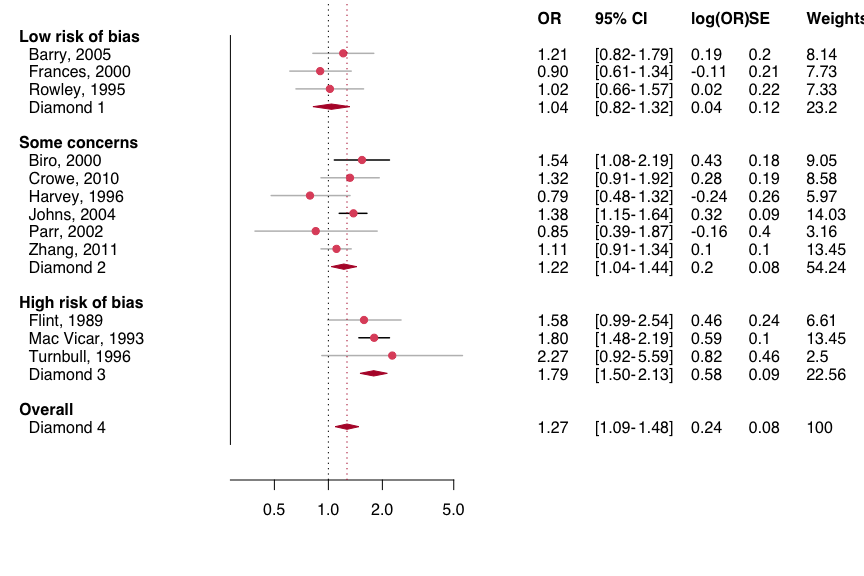

Let's try some more customization options. First, we will make the size of the dots proportional to the study weights with `scaledot.by` (a numeric vector, for example containing sample sizes or weights). We will remove the diamond weights to get better relative scaling here (in `scaledot.by`, the maximum value is taken as the reference value). We will also change the character type with `char`, and add text underneath the x-axis with `favorlabs`. Finally, we will shade every other row using the `shade.every` argument. This latter argument can take on any value, to allow visual grouping by line color.

```r
weights <- exdf2$weights
weights[c(4,11,15,16)] <- NA
forplo(exdf2[,1:3],
       groups=exdf2$groups,
       grouplabs=c('Low risk of bias',
                   'Some concerns',
                   'High risk of bias',
                   'Overall'),
       left.align=TRUE,
       add.columns=exdf2$weights,
       add.colnames=c('Weights'),
       col=2,
       char=15,
       ci.edge=FALSE,
       diamond=c(4,11,15,16),
       diamond.col='#b51b35',
       scaledot.by=weights,
       favorlabs=c('Favours other models','Favours midwife-led'),
       shade.every=1)
```

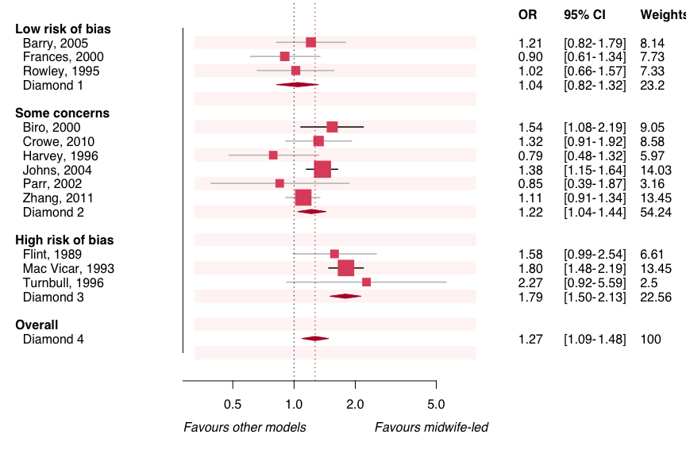

Other possibilities include the option to `sort` rows by effect size, to invert odds ratios and confidence intervals using `flipbelow1=TRUE` or by specifying the relevant rows with `fliprow`, adding ticks to the left bar or right bar (`leftbar.ticks` and `rightbar.ticks`, which require `left.bar` and `right.bar` to be `TRUE`), and to increase (or decrease) the empty space between groups by changing `group.space`. Further, the dots and CIs can also be colored by a grouping variable, using the arguments `fill.by` for the grouping variable and `fill.colors` to designate the corresponding colors. The font can be set with `font`. Note: monospace fonts don't work well with the automatic setting of plot margins.

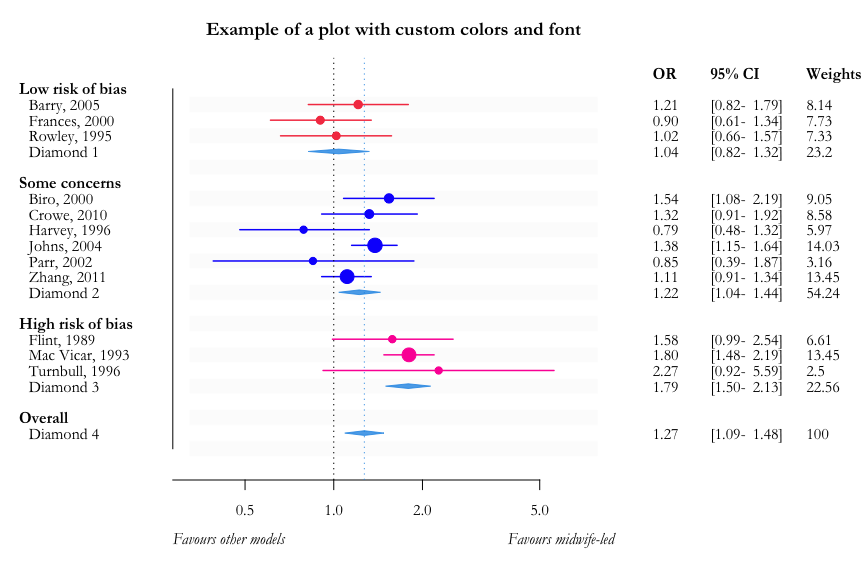

```r
forplo(exdf2[,1:3],
       groups=exdf2$groups,
       grouplabs=c('Low risk of bias',
                   'Some concerns',
                   'High risk of bias',
                   'Overall'),
       left.align=TRUE,
       add.columns=exdf2$weights,
       add.colnames=c('Weights'),
       ci.edge=FALSE,
       diamond=c(4,11,15,16),
       diamond.col=adjustcolor(4,0.8),
       scaledot.by=weights,
       favorlabs=c('Favours other models','Favours midwife-led'),
       shade.every=1,
       shade.col='gray',
       font='Garamond',
       fill.by=exdf2$groups,
       fill.colors=c('#f54251','#1403fc','#fc03a5',1),
       title='Example of a plot with custom colors and font',
       margin.left=9)
```

## Adding legends and arrows underneath the plot

It is also possible to automatically generate a customizable legend for the `fill.by` grouping variable, by providing individual group labels in `fill.labs` and by setting `legend=TRUE`. The horizontal and vertical placement (relative to the original position) of the legend are controlled by `legend.hadj` and `legend.vadj`. Further, the spacing between legend items can be altered by specifying a `legend.spacing` (the default being 1). Lastly, here we will introduce the option to include arrows underneath the plot, by setting `add.arrow.left` and `add.arrow.right` to `TRUE`, and to specify their length with `arrow.left.length` and `arrow.right.length`. Finally, the relative vertical placement of these arrows can be set by `arrow.vadj`.

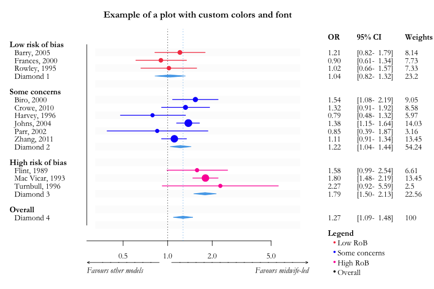

```r
forplo(exdf2[,1:3],
       groups=exdf2$groups,
       grouplabs=c('Low risk of bias',
                   'Some concerns',
                   'High risk of bias',
                   'Overall'),
       left.align=TRUE,
       add.columns=exdf2$weights,
       add.colnames=c('Weights'),
       ci.edge=FALSE,
       diamond=c(4,11,15,16),
       diamond.col=adjustcolor(4,0.8),
       scaledot.by=weights,
       favorlabs=c('Favours other models','Favours midwife-led'),
       add.arrow.left=TRUE,
       add.arrow.right=TRUE,
       arrow.left.length=8,
       arrow.right.length=16,
       shade.every=1,
       shade.col='gray',
       font='Garamond',
       fill.by=exdf2$groups,
       fill.colors=c('#f54251','#1403fc','#fc03a5',1),
       fill.labs=c('Low RoB','Some concerns','High RoB','Overall'),
       legend=TRUE,
       legend.vadj=1,
       legend.hadj=1,
       legend.spacing=2.5,
       title='Example of a plot with custom colors and font',
       margin.left=9)
```

## Saving plots with forplo

**forplo** can save plots as one of two types, .png or .wmf. For this, the argument `save` should be set to `TRUE`, the desired folder should be specified in `save.path`, the name of the plot in `save.name`, and the file type should be designated with `save.type` (default is .png). The width and height of the plot (in inches) can be set with `save.width` and `save.height`.

## More examples: regression models

**forplo** also accepts models of class `lm`, `glm` and `coxph` to enable fast visualization of commonly used regression models. P-values given by `summary()` are shown, and profiling confidence intervals computed. The corresponding effect measure (e.g. odds ratios for logistic regression models) is automatically shown. All customization options are still available when using models as input.

First let's define the models.

```r
mod1 <- lm(Sepal.Length~Sepal.Width+Species+Petal.Width+Petal.Length,iris)
mod2 <- glm(as.numeric(status==2)~scale(age)+sex+
              ph.ecog+scale(ph.karno)+scale(pat.karno)+
              scale(meal.cal)+scale(wt.loss),survival::lung,family=binomial)
survmod <- survival::coxph(survival::Surv(time,status)~scale(age)+sex+
                        ph.ecog+scale(ph.karno)+scale(pat.karno)+
                        scale(meal.cal)+scale(wt.loss),survival::lung)
```

This is the default plot when entering a linear regression model.

```r
forplo(mod1)
```

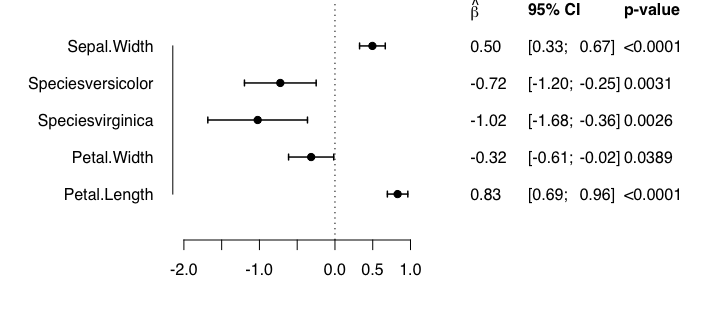

The following are some examples of customized plots using `lm`, `glm` and `coxph` models as input.

```r
forplo(mod1,
       row.labels=c('Sepal width','Versicolor','Virginica','Petal width','Petal length'),
       groups=c(1,2,2,3,3),
       grouplabs=c('Sepal traits','Species','Petal traits'),
       shade.every=1,
       shade.col='gray',
       left.align=TRUE,
       xlim=c(-2,2),
       title='Linear regression with grouped estimates')
```

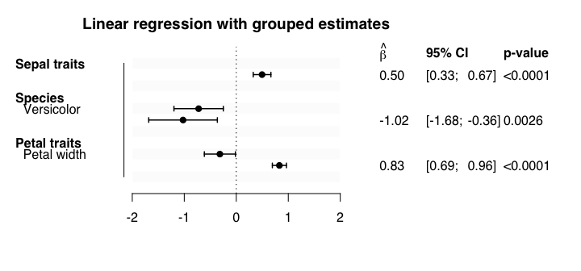

The plot window may have to be resized to show all labels optimally.

```r
forplo(mod2,
       sort=TRUE,
       favorlabs=c('Lower mortality','Higher mortality'),
       shade.every=1,
       ci.edge=FALSE,
       char=18,
       row.labels=c('Age',
                    'Female sex',
                    'ECOG performance',
                    'Karnofsky performance,\nphysician-assessed',
                    'Karnofsky performance,\npatient-assessed',
                    'Calories per meal',
                    'Weight loss, last 6m'),
       title='Logistic regression, sorted by OR')
```

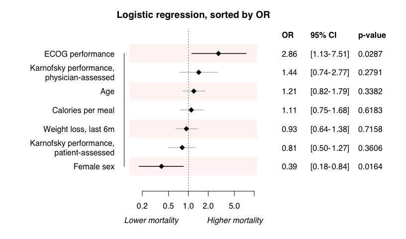

```r
forplo(survmod,
       row.labels=c('Age',
                    'Female sex',
                    'ECOG performance',
                    'Karnofsky performance,\nphysician-assessed',
                    'Karnofsky performance,\npatient-assessed',
                    'Calories per meal',
                    'Weight loss, last 6m'),
       sort=TRUE,
       flipbelow1=TRUE,
       flipsymbol=', inverted',
       fill.by=c(1,1,2,2,2,3,3),
       fill.colors=c(1,2,'#3483eb'),
       scaledot.by=abs(coef(survmod)),
       shade.every=2,
       font='Helvetica',
       title='Cox regression, sorted by HR, inverted HRs<1, scaled dots by effect size',
       right.bar=TRUE,
       rightbar.ticks=TRUE,
       leftbar.ticks=TRUE)
```

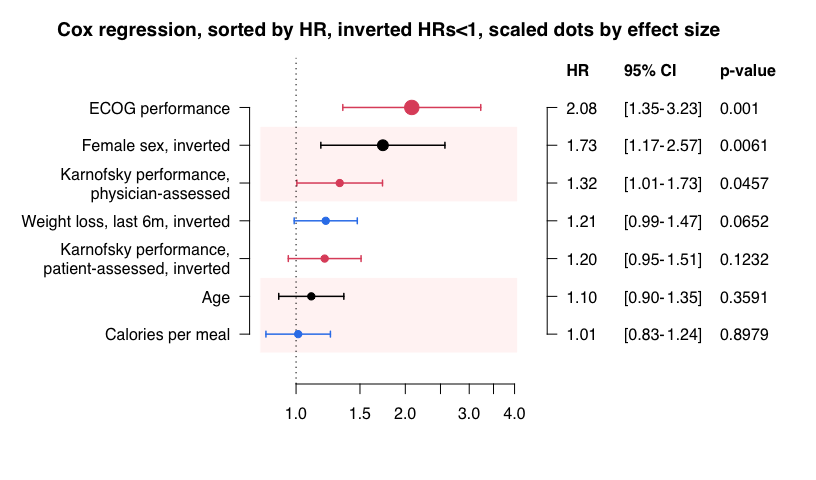

## References

McKenzie JE and Brennan SE in Higgins JPT, Thomas J, Chandler J, Cumpston M, Li T, Page MJ, Welch VA (editors). *Cochrane Handbook for Systematic Reviews of Interventions*, version 6.2 (updated February 2021). Cochrane, 2021. Available from www.training.cochrane.org/handbook.